# Capitulo 2

```r
# Librerias a instalar en caso de que de error
# install.packages('plot3D')

# Bibliotecas a utilizas
library(plot3D)
```

Codigo de ejemplo.

## Simulaciones en R

Simulación 2.1. A continuación simulamos tres trayectorias de paseo aleatorio unidimensional. Suponemos que la caminata comienza en cero y especificamos la probabilidad en 0.6 y el número de pasos como 25.

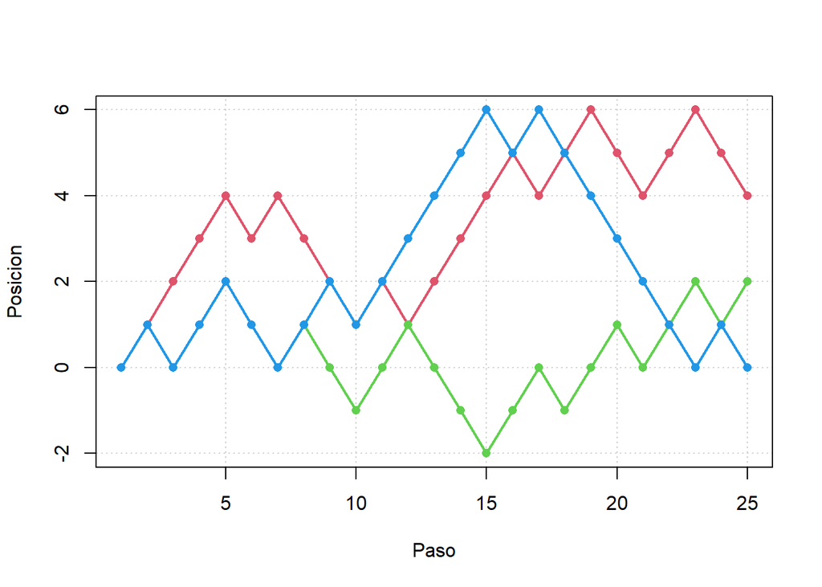

```r
# inicializamos las variables
ntraj <- 3
p <- 0.6
nsteps <- 25

# asignamos una semilla
set.seed(45568223)

# definimos la caminata como una matriz
walk <- matrix(NA, nrow = nsteps, ncol = ntraj)

# Simulamos la trayectoria
for (j in 1:ntraj){
  walk[1,j] <- 0
  for (i in 2:nsteps)
    walk[i,j] <- ifelse(runif(1)<p, walk[i-1, j]+1, walk[i-1,j]-1)
}

# graficamos las trayectorias
matplot(walk, type="l", lty=1, lwd=2, col=2:4,
ylim=c(range(walk)), xlab="Paso", ylab="Posicion",
panel.first=grid())
points(1:nsteps, walk[,1], pch=16, col=2)
points(1:nsteps, walk[,2], pch=16, col=3)
points(1:nsteps, walk[,3], pch=16, col=4)
```

### Simulación 2.2 El código abajo simula y gráfica en dos dimenciones una caminata aleatoria con un total de 10,000 pasos, inicializando en el origen.

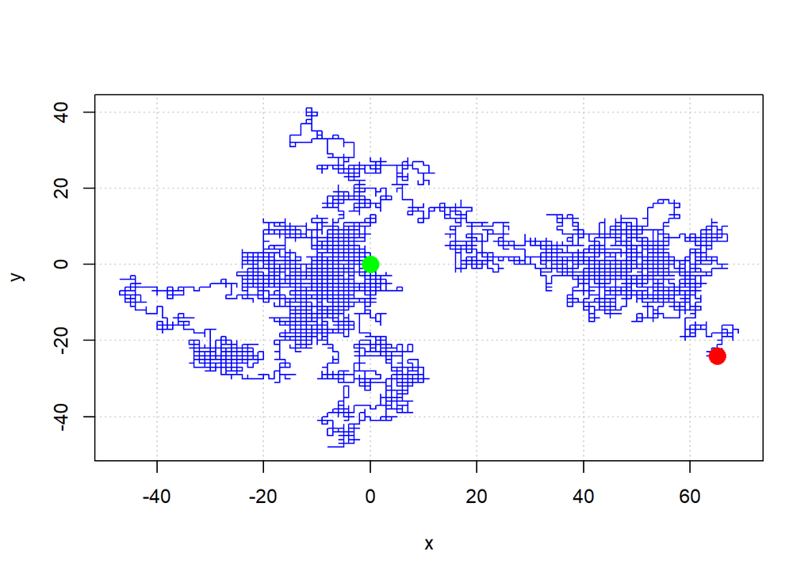

```r
# especificamos el numero de pasos
nsteps <- 10000

# inicializamos la semilla
set.seed(607335)

# Defiinimos la caminata como una matriz
walk <- matrix(NA, nrow = nsteps, ncol =2)

# Declaramos el punto de inicio.
walk[1,] <- c(0,0)

# Definimos los pasos aleatorios
rstep<- matrix(c(1, 0, -1, 0, 0, 1, 0, -1), nrow=4, ncol=2,
byrow=TRUE)

# sumulamos trajectorias
for (i in 2:nsteps)
walk[i,]<- walk[i-1,] + rstep[sample(1:4, size=1),]
# graficamos las trayectorias
plot(x=walk[,1], y=walk[,2], type="l", col="blue",
xlim=range(walk[,1]), ylim=range(walk[,2]), xlab="x",
ylab="y", panel.first=grid())
# agregamos el punto de origen
points(cbind(walk[1,1], walk[1,2]), pch=16, col="green",
cex=2)
# añadimos los puntos finales
points(cbind(walk[nsteps,1],walk[nsteps,2]), pch=16,
col="red", cex=2)
```

### Simulacion 2.3

El siguiente codigo simula y gráfica en tres dimenciones una caminata aleatoria con 5,000 pasos.

```r
# especificamos el numero de pasos
nsteps<- 5000

# Especificamos la semilla
set.seed(830126)

# Definimos la caminata como una matriz
walk<- matrix(NA, nrow=nsteps, ncol=3)

# Asignamos el punto inicial
walk[1,]<- c(0,0,0)

# definimos los pasos aleatorios
rstep<- matrix(c(1,0,0,-1,0,0,0,1,0,0,-1,0,0,0,1,0,0,-1),
nrow=6, ncol=3, byrow=TRUE)

# Simulamos las tryectorias
for (i in 2:nsteps)
walk[i,]<- walk[i-1,]+rstep[sample(1:6, size=1),]

# Graficamos las trajectorias
lines3D(walk[,1], walk[,2], walk[,3], col="blue",
xlim=range(walk[,1]), ylim=range(walk[,2]),
zlim=range(walk[,3]), xlab="x", ylab="y", zlab="z", bty="b2",
ticktype="detailed")

# añadimos pundo de partida
points3D(x=walk[1,1], y=walk[1,2], z=walk[1,3], add=TRUE,
pch=16, col="green", cex=2)

# añadimos el punto final
points3D(walk[nsteps,1], walk[nsteps,2], walk[nsteps,3],
add=TRUE, pch=16, col="red", cex=2)
```

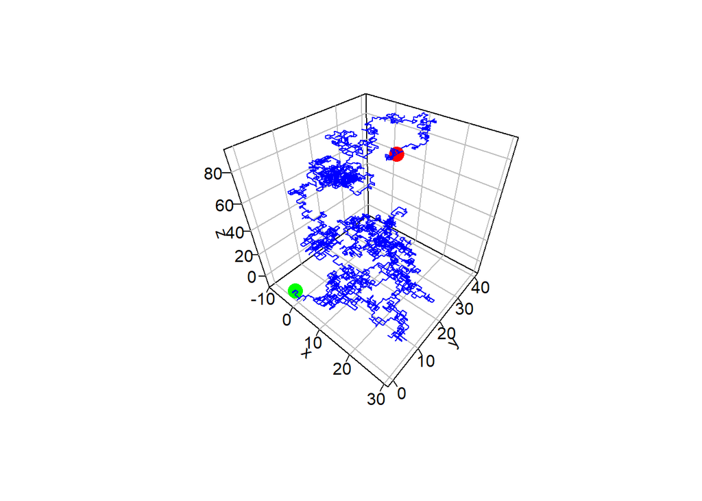

### Aplicacion de una caminata aleatoria

Ejemplo:

```r
# Inicializamos variables
p <- 0.55
i <- 10
N <- 20
ntraj <- 100000

# Inicializamos la caminata como un vector
walk <- c()

# Inicializamos contadores
nNs <- 0
nzeros <- 0
ngames <- 0

# Especificamos la semilla
set.seed(30112443)

# Simulamos trajectorias hasta alcanzar N o 0
for (j in 1 : ntraj){
  walk[1] <- i
  k <- 2
  repeat{
    walk[k] <- ifelse(runif(1)<p, walk[k-1] + 1, walk[k-1]-1)
    ngames <- ngames + 1

    if (walk[k] == N){
      nNs <- nNs + 1
      break
    }

    else if(walk[k] == 0){
      nzeros <- nzeros +1
      break
    }
  k <- k + 1
  }
}

print(prob.Ns <- nNs/ntraj)
```

```
## [1] 0.88279
```

```r
print(prob.zeros <- nzeros/ntraj)
```

```
## [1] 0.11721
```

```r
print(mean.ngames<- ngames/ntraj)
```

```
## [1] 76.18866
```

A continuación, podemos trazar el gráfico de las probabilidades en función de p, para nuestros valores específicos de i = 10 y N = 20. A continuación se muestra la sintaxis y el gráfico. La curva verde representa la probabilidad de alcanzar N, mientras que la roja muestra la probabilidad de ruina.

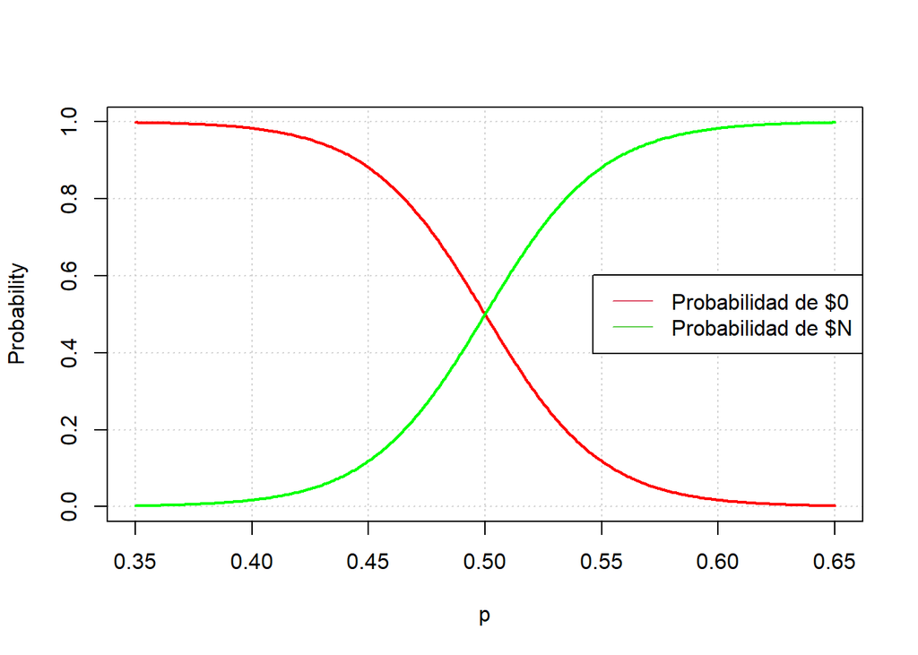

```r
# Inicializamos los parametros
p<- seq(0.35,0.65,0.001)
i<- 10
N<- 20
q<- 1-p
p.ruin<- ifelse(p==0.5,(N-i)/N,((q/p)^i-(q/p)^N)/(1-(q/p)
^N))


# Graficamos los grafos
plot(p,p.ruin, type = "l", lwd=2, col = "red", xlab="p",
ylab="Probability", panel.first = grid())
lines(p, 1-p.ruin, lwd=2, col = "green")
legend("right", c("Probabilidad de $0", "Probabilidad de $N"),
lty=1, col=2:3)
```

Finalmente, graficamos los grafos del número esperado de juegos contra p. El código y el resultado se presentan a continuación.

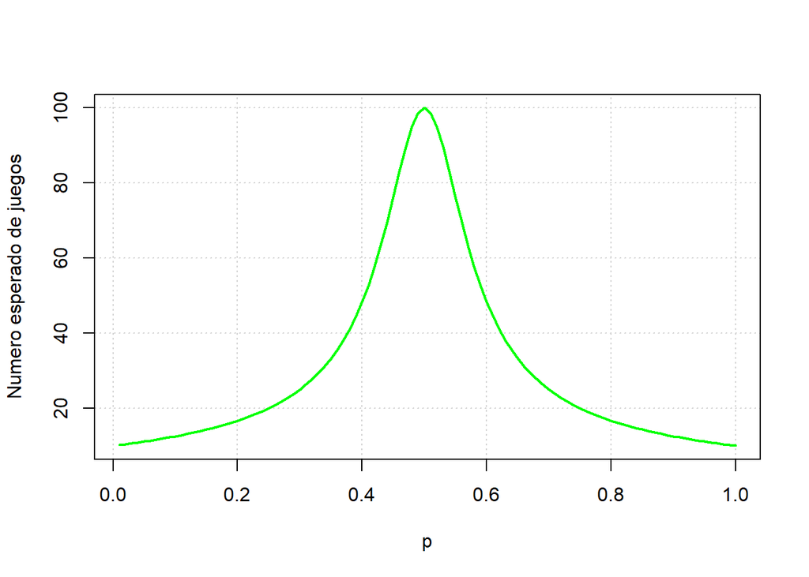

```r
p <- seq(0.01, 1, 0.01)
i <- 10
N <- 20
q <- 1-p
E.ngames <- ifelse(p==0.5,i*(N-i),(i-N*(1-(q/p)^i)/(1-(q/p) ^N))/(1-2*p))

plot(p, E.ngames, type="l", lwd=2, col="green", xlab="p",
ylab="Numero esperado de juegos", panel.first=grid())
```

```r
# Especificamos la matriz de transicion de probabilidad
tm<- matrix(c(1,0,0,0,0,0,1/4,0,1/4,1/4,0,1/4,0,1/2,0,
1/2,0,0,0,1/4,1/4,0,1/4,1/4,1/3,0,0,1/3,0,1/3,0,1/3,0,1/3,1/
3,0), nrow=6, ncol=6, byrow=TRUE)

# Inicializamos contador
nsec<- 0

# Estimamos el numero esperado de segundos previstos
p<- matrix(NA, nrow=172, ncol=6)
p[1,]<- c(0, 0, 0, 1, 0, 0)

# Simulamos las trayectorias
for (i in 2:172) {
  p[i,]<- p[i-1,]%*%tm
  nsec<- nsec+(i-1)*(p[i,1]-p[i-1,1])
}

print(nsec)
```

```
## [1] 9.967213
```

# Ejercicios:

### Ejercicio 2.1

En teoria, $E(X_{50})=((2)(0.3)-1)(50) = -20~and~Var(X_{50})=(4)(0.3)(1/0.3)(50) = 42$

```r
# Especificamos los parametos
p <- 0.3
n <- 50
ntraj<- 10000

# Especificamos la semilla
set.seed(546675)

# Definimos la caminata como una matriz
walk<- matrix(NA, nrow=n, ncol=ntraj)

# Simulamos las trayectorias
for (j in 1:ntraj) {
 walk[1,j]<- 0
 for (k in 2:n) {
   walk[k,j]<- ifelse(runif(1)<p, walk[k-1,j]+1, walk[k-1,j]-1)
 }
}

mean(walk[50,])
```

```
## [1] -19.5824
```

```r
var(walk[50,])
```

```
## [1] 42.16583
```

El valor empíricos se aproximan bastante a los teóricos.

## Ejercicio 2.2

Consideremos una caminata aleatoria unidimensional simétrico que se origina en 0. - Simulamos 10,000 trayectorias con 1,000 pasos cada una. ¿Cuántas de las trayectorias están en el punto 0 en el paso 1,000? - Encuentra la probabilidad teorica de volver a 0 en el paso 1,000 comparar con el valor empirico.

```r
# Inicializamos los pasos en cero
nzeros <- 0

# Especificamos la semilla
set.seed(675572)

# Definimos la caminata como una matriz
walk <- c()

# Simulamos las trayectorias
for (j in 1: 10000){
  walk[1] <- 0
  for (i in 2 : 1001)
    walk[i] <- ifelse(runif(1)<0.5, walk[i-1]+1, walk[i-1]-1)
 if (walk[1001]==0) nzeros=nzeros+1
}
print(nzeros)
```

```
## [1] 253
```

a)La probabilidad teórica de volver en el paso 1,000 es:
$$P(X_{1000} = 0\mid X_0 =0)\begin{pmatrix}1000\\500\end{pmatrix}\left(\frac{1}{2}\right)^{1000} = 0.025$$
Esta cantidad se ha calculado en R:

```r
choose(1000, 500)*0.5 ^1000
```

```
## [1] 0.02522502
```

# Ejercicio 2.3

Simular 10,000 trajectorias de pasos aleatorias siméticos en 1D. 2D Y 3D que comiencen en el origen y continúen durante un máximo de 1,000 pasos.

- Calcula cuántos de ellos volvieron al origen al menos una vez. Compara los resultados para diferentes dimensiones. Sugerencia: Termine una trayectoria cuando vuelva al origen.
- Considere sólo las trayectorias que volvieron al origen dentro de los 1.000 pasos. Calcule el número medio de pasos que han tardado estas trayectorias en volver al origen. Compare los resultados para diferentes dimensiones.

```r
# Inicializamos las variables con cero
n1D<- 0
n2D<- 0
n3D<- 0

# Especificamos la semilla
set.seed(300799)

# Definimos la caminata 1D como vector
walk1D<- c()
nsteps1D<- c()

# Simulamos las trayectorias de 1D
for (j in 1:10000)
 {
  # Asignamos el valor inicial a cero
   walk1D[1]<- 0
   for (i in 2:1001)
   {
     walk1D[i]<- ifelse(runif(1)<0.5, walk1D[i-1]+1, walk1D[i-1]-1)
     if (walk1D[i]==0) {
       n1D=n1D+1
       break }
   }
   nsteps1D[j]=i
}


# Definimos la caminata aleatoria 2D como una matriz
walk2D <- matrix(NA, nrow = 1001, ncol = 2)
nsteps2D <- c()

# Definimos los pasos aleatorios
rstep2D<- matrix(c(1, 0, -1, 0, 0, 1, 0, -1), nrow=4, ncol=2, byrow=TRUE)

# Simulamos las trayectorias de 2D
for (j in 1 : 10000)
{
  # Asignamos el valor inicial al origen
  walk2D[1,] <- c(0,0)
  for (i in 2:1001)
  {
    walk2D[i,] <- walk2D[i-1,]+rstep2D[sample(1:4, size=1),]
    if (walk2D[i,1]==0 & walk2D[i,2]==0) {
      n2D = n2D + 1
      break  }
  }
  nsteps2D[j] = i
}

# Definimos la caminata 3D como una matriz
walk3D<- matrix(NA, nrow=1001, ncol=3)
nsteps3D<- c()

# Definimos los paso aleatorios
rstep3D<- matrix(c(1, 0, 0,-1, 0, 0, 0, 1, 0, 0, -1, 0, 0, 0, 1, 0, 0, -1),
nrow=6, ncol=3, byrow=TRUE)

# Simulamos las trayectorias de 3D
for (j in 1:10000)
{
  # Iicializamos el valor inicial en el origen
  walk3D[1,]<- c(0,0,0)
  for (i in 2:1001)
  {
    walk3D[i,]<- walk3D[i-1,]+rstep3D[sample(1:6, size=1),]

    if (walk3D[i,1]==0 & walk3D[i,2]==0 & walk3D[i,3]==0) {
      n3D=n3D+1
      break }
  }
  nsteps3D[j]=i
}

# Mostramos los valores
print(n1D)
```

```
## [1] 9756
```

```r
print(n2D)
```

```
## [1] 6759
```

```r
print(n3D)
```

```
## [1] 3329
```

Aproximadamente el 97,6% de las trayectorias 1D volvieron a 0, alrededor del 67,6% de las trayectorias 2D volvieron a (0, 0), y sólo el 33,3% de las trayectorias 3D volvieron a (0, 0, 0).

- El número medio de pasos que tardaron esas trayectorias en volver al origen se calcula como:

```r
mean(nsteps1D[nsteps1D!=1001])
```

```
## [1] 27.47499
```

```r
mean(nsteps2D[nsteps2D!=1001])
```

```
## [1] 61.47625
```

```r
mean(nsteps3D[nsteps3D!=1001])
```

```
## [1] 27.83689
```

El 97,6% de las trayectorias 1D que volvieron al origen, lo hicieron en 27,47 pasos, por término medio. El 67,6% de las trayectorias 2D que volvieron al origen lo hicieron en 61,48 pasos de media. El 33,3% de las trayectorias 3D que volvieron al origen lo hicieron en 27,84 pasos de media.

## Ejercicio 2.4

Simule 10.000 trayectorias de un paseo aleatorio simétrico bidimensional que comienza en el origen y continúa durante un máximo de 1.000 pasos. - Estimar la probabilidad de que una trayectoria llegue a chocar con la barrera vertical $x=30$. - Estimar el número medio de pasos que tarda una trayectoria en chocar con la barrera, siempre que lo haya hecho dentro de los 1.000 pasos. - Estimar el valor esperado de la coordenada y en el momento en que el paseo aleatorio choca con la barrera. ¿Cuál debería ser este valor desde el punto de vista teórico? Pista: dedúcelo a partir de un argumento de simetría.

El siguiente script R simula las trayectorias y las termina si se alcanza la barrera. En caso contrario, las trayectorias continúan durante 1.000 pasos. Se cuenta el número total de trayectorias que alcanzan la barrera. También se registra el número de pasos (para la parte (b)) y la coordenada 𝑦𝑦 (para la parte (c)).

```r
# Inicializamos el valor
nhits <- 0

# Especificamos la semilla
set.seed(50118)

# Definimos la caminata como una matriz
walk <- matrix(NA, nrow = 1001, ncol = 2)
nsteps <- c()
ycoord <- c()

# Definimos los pasos aleatorios
rstep <- matrix(c(1, 0, -1, 0, 0, 1, 0, -1), nrow=4, ncol=2, byrow=TRUE)

# Simulamos las trayectorias
for (j in 1:10000)
  {
    # Inicializamos el valor inicial en el origen
    walk[1,]<- c(0,0)
    for (i in 2:1001)
    {
      walk[i,]<- walk[i-1,] + rstep[sample(1:4, size=1),]
      if (walk[i,1]==30) {
        nhits=nhits+1
        break }
    }
  nsteps[j]<- i
  ycoord[j]<- ifelse(i==1001, 99999, walk[i,2])
}
print(nhits)
```

```
## [1] 1764
```

Así, de las 10.000 trayectorias, 1.764 chocaron contra la barrera vertical. Por tanto, la probabilidad estimada de chocar con la barrera es de 0,1764.

2. El número medio de pasos que tarda una trayectoria en chocar contra la barrera, siempre que lo haya hecho dentro de los 1.000 pasos, se estima como:

```r
mean(nsteps[nsteps!=1001])
```

```
## [1] 623.2053
```

El 17,64% de las trayectorias que terminaron en la barrera tardaron una media de 623,2 pasos en alcanzarla.

1. Estime el valor esperado de la coordenada 𝑦𝑦 en el momento en que el paseo aleatorio alcanza la barrera. ¿Cuál debería ser este valor desde el punto de vista teórico? Sugerencia: dedúzcalo a partir de un argumento de simetría.

```r
mean(ycoord[ycoord!=99999])
```

```
## [1] 0.1066364
```

La coordenada 𝑦𝑦 media estimada para el 17,64% de las trayectorias que chocaron contra la barrera fue 0,1066. Desde el punto de vista teórico, utilizando la simetría del paseo aleatorio, podemos argumentar que la coordenada y debería ser igual a 0.

## Ejercicio 2.5

Simula 100 trayectorias de un paseo aleatorio simétrico bidimensional que comienza en el origen y continúa durante 1.000 pasos o hasta que choca con una barrera. El valor de la barrera varía entre x = 1 y x = 50. Represente gráficamente la probabilidad empírica de chocar con la barrera frente al valor de la barrera. Discute el patrón que observas.

```r
# Inicializamos el numero de ¿golpes?
Nhits <- c()

# Especificamos la semilla
set.seed(96770)

# Definimos la caminata como una matriz
walk <- matrix(NA, nrow = 1001, ncol = 2)

# Definimos los pasos aleatorios
rstep <- matrix(c(1, 0, -1, 0, 0, 1, 0, -1), nrow=4, ncol=2, byrow=TRUE)

# variando el valor de la barrera
for (barrier in 1:50) {
  nhits<- 0
  # Simulamos la trayectoria
  for (j in 1:100)
  {
    # Inicializamos el valor inicial en el origen
     walk[1,]<- c(0,0)
     for (i in 2:1001)
     {
       walk[i,]<- walk[i-1,] + rstep[sample(1:4, size=1),]

       if (walk[i,1]==barrier) {
         nhits=nhits+1
         break }
     }
  }
  Nhits[barrier]=nhits
}

print(Nhits)
```

```
##  [1] 93 94 93 94 87 85 72 66 66 66 61 61 66 43 49 49 44 46 37 38 39 31 33 29 30
## [26] 28 19 24 17 18 23 13 22 12  8  9  8 10  8 11  6  8  4  7  4  6  3  4  4  1
```

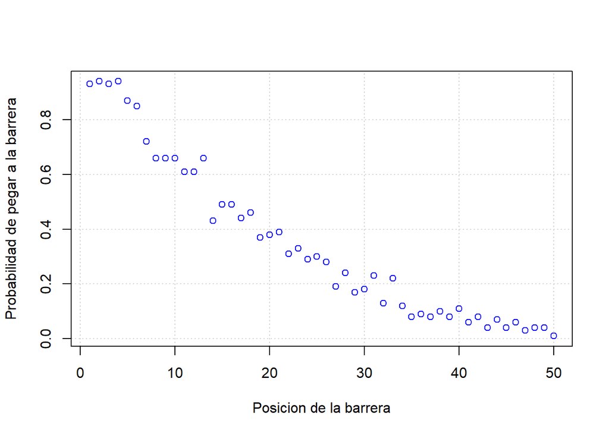

```r
plot(1:50, Nhits/100, col="blue", xlab="Posicion de la barrera", ylab="Probabilidad de pegar a la barrera", panel.first=grid())
```

Vemos que a medida que el valor de la barrera aumenta de 1 a 50, la probabilidad estimada de chocar con esta barrera disminuye de 0,93 a 0,01, de forma ligeramente curvilínea (convexa hacia abajo).

## Ejercicio 2.6

Simule 1.000 trayectorias de un paseo aleatorio simétrico bidimensional que comienza en el origen y continúa hasta que alcanza un lado de un cuadrado centrado en el origen y que tiene una longitud lateral de 20. Estima el número medio de pasos que tarda el paseo aleatorio en llegar al cuadrado.

```r
# Definimos la caminata como un dataframe
walk <- data.frame()

# Definimos el numero de pasos como vector
nsteps <- c()

# Fijamos la semilla
set.seed(37440)

# Definimos los pasos aleatorios
rstep<- matrix(c(1, 0, -1, 0, 0, 1, 0, -1), nrow=4, ncol=2, byrow=TRUE)

# Simulamos trayectorias
for (j in 1:1000)
 {

 walk[1,1]<- 0
 walk[1,2]<- 0
 i<- 2

 repeat{
 walk[i,]<- walk[i-1,] + rstep[sample(1:4, size=1),]
 if (walk[i,1]==10 | walk[i,1]==-10 | walk[i,2]==10 | walk[i,2]==-10)
 { break }
 else i=i+1
 }

 nsteps[j]=i
}


mean(nsteps)
```

```
## [1] 120.898
```

## Ejercicio 2.7

```r
# Definimos los parametros
p <- 0.47
ntraj <- 1000

# Fijimos la semilla
set.seed(314159)

# Definimos la caminata cmo una matriz
walk <- data.frame(NULL)

# Inicializamos los contadores
n80 <- 0
n10 <- 0
ngames <- 0

# Simulamos trajectorias
for (j in 1:ntraj){
  walk[1,j] <- 40
  k <- 2
  repeat{
    walk[k,j] <- ifelse(runif(1) < p, walk[k-1, j]+1, walk[k-1,j]-1)
    if (walk[k,j] == 80){
      n80<- n80 +1
      break
    }
    if (walk[k,j] ==10){
      n10 <- +1
      break
    }
    k <- k+1
    ngames <ngames +1
  }
}

print(prop.n80<- n80/ntraj)
```

```
## [1] 0.007
```

```r
print(ang.ngames <- ngames / ntraj)
```

```
## [1] 0
```

## Ejercicio 2.8

Un estudiante visita un museo de Historia Antigua que está abierto entre las 9 de la mañana y las 6 de la tarde. Entra en el museo a las 9 de la mañana y recorre las salas de forma aleatoria, pasando 30 minutos en cada sala y eligiendo una puerta al azar. En la imagen se muestra el plano del museo. ¿Cuánto tiempo pasará el estudiante en el museo, por término medio? ¿Espera ¿espera salir del museo antes de que cierre? Escribe la fórmula y utiliza R para calcular el resultado.

$$\begin{bmatrix}B&C&E\\A&D&F\end{bmatrix}$$

```r
# especificando la matriz de probabilidad de transición
tm<- matrix(c(1,0,0,0,0,0,0,1/3,0,1/3,0,1/3,0,0,0,1/2,0,1/2,0,0,0,0,0,
1/3,0,1/3,1/3,0,0,1/2,0,1/2,0,0,0,0,0,0,1/2,0,0,1/2,0,0,0,0,0,1,0),
nrow=7, ncol=7, byrow=TRUE)

# Inicializamos un contador
ntrans<- 0

# Calculamos el numero esperado de transiciones
p<- matrix(NA, nrow=146, ncol=7)
p[1,]<- c(0,1,0,0,0,0,0)
for (i in 2:146) {
 p[i,]<- p[i-1,]%*%tm
 ntrans<- ntrans+(i-1)*(p[i,1]-p[i-1,1])
}

print(ntrans)
```

```
## [1] 12.94225
```

Así, el alumno realizará, por término medio, 12,94225 transiciones entre las salas. Como pasa 30 minutos en cada sala, la duración media total de la visita será de (30)(12,94225)=388,2675 minutos (o 6 horas y 28,3 minutos). En una visita “media”, habrá terminado antes de que cierre el museo.